## Course: Computational Thinking for Governance Analytics

### Prof. José Manuel Magallanes, PhD

# Session 3: [Modeling Governance Complexity in R](https://github.com/EvansDataScience/ComputationalThinking_Gov_3)

In this session, we will learn some basics on modeling, namely two important techniques:

1. Linear Regression
2. Logistic Regression

This session will work with a collection of indexes:

```r
link='https://raw.githubusercontent.com/EvansDataScience/data/master/allIndexes.csv'
indexes=read.csv(link,stringsAsFactors = F) #this turns strings into categorical variables

names(indexes)
```

```
## [1] "Country"         "ISO"             "corruptionIndex" "scoreEconomy"
## [5] "scorepress"      "environment"     "presscat"        "environmentCat"
```

- The *corruptionIndex* is the *Corruption Perception Index* (CPI) produced by [Transparency International](https://www.transparency.org/).
- The *scoreEconomy* is the *Economic Freedom Index* (EFI) produced by [Fraser Institute](https://www.fraserinstitute.org).
- The *environment* and *environmentCat* represent the *Environment Performance Index* (EPI) produced by [Yale University and Columbia University in collaboration with the World Economic Forum](https://epi.envirocenter.yale.edu/). The latter is a dichotomic variable.
- The *scorepress* and *presscat* are data about the *World Press Freedom Index* (WPFI) produced by [Reporters Without Borders](https://rsf.org/en/world-press-freedom-index). The latter is a ordinal variable.

We can check descriptives:

```r
summary(indexes)
```

```
##    Country              ISO            corruptionIndex  scoreEconomy
##  Length:129         Length:129         Min.   :14.00   Min.   :2.920
##  Class :character   Class :character   1st Qu.:31.00   1st Qu.:6.320
##  Mode  :character   Mode  :character   Median :40.00   Median :6.920
##                                        Mean   :45.42   Mean   :6.829
##                                        3rd Qu.:58.00   3rd Qu.:7.510
##                                        Max.   :90.00   Max.   :8.810
##    scorepress     environment       presscat     environmentCat
##  Min.   : 8.59   Min.   :37.10   Min.   :1.000   Min.   :0.0000
##  1st Qu.:49.12   1st Qu.:59.25   1st Qu.:2.000   1st Qu.:0.0000
##  Median :59.63   Median :70.84   Median :2.000   Median :1.0000
##  Mean   :58.45   Mean   :69.39   Mean   :2.093   Mean   :0.5426
##  3rd Qu.:66.89   3rd Qu.:81.26   3rd Qu.:3.000   3rd Qu.:1.0000
##  Max.   :80.96   Max.   :90.68   Max.   :3.000   Max.   :1.0000
```

And data types:

```r
str(indexes,width=70,strict.width='cut')
```

```
## 'data.frame':    129 obs. of  8 variables:
##  $ Country        : chr  "New Zealand" "Denmark" "Finland" "Sweden" ..
##  $ ISO            : chr  "NZL" "DNK" "FIN" "SWE" ...
##  $ corruptionIndex: int  90 90 89 88 86 85 84 83 82 81 ...
##  $ scoreEconomy   : num  8.48 7.77 7.75 7.65 8.44 7.67 8.81 7.74 7.9..
##  $ scorepress     : num  79.5 80.7 81 77.2 77.8 ...
##  $ environment    : num  88 89.2 90.7 90.4 86.9 ...
##  $ presscat       : int  3 3 3 3 3 3 1 3 3 3 ...
##  $ environmentCat : int  1 1 1 1 1 1 1 1 1 1 ...
```

Keep in mind thta the last two ones are categorical. *Presscat* is a categorical representation of the press freedom index:

```r
table(indexes$presscat)
```

```
##
##  1  2  3
## 23 71 35
```

And *enviromentCat* is a representation of environment performance index:

```r
table(indexes$environmentCat)
```

```
##
##  0  1
## 59 70
```

The former is ordinal (the higher the better), while the second is a dichotomous variable (good or bad performance). _____

## Linear Regression

You need a linear regression when your variable of interest is continuous (a measurement). In this case, I will simply use the EPI as my *explanandum* (Y):

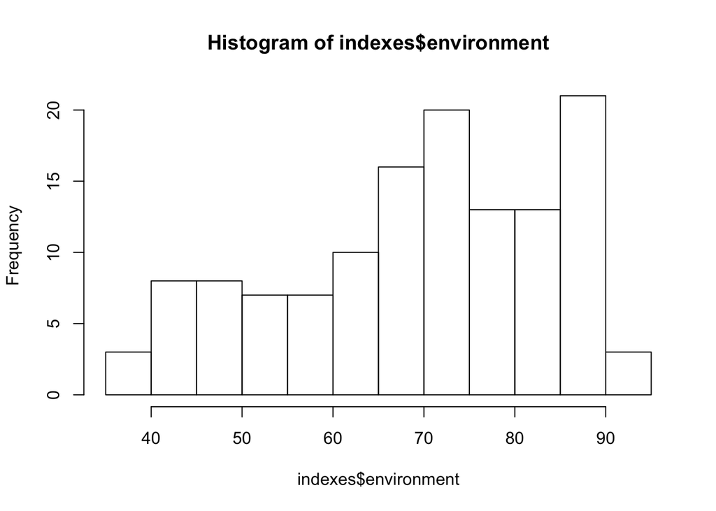

```r
hist(indexes$environment)
```

The other variables in the set could be used as our *explanans* (X), that is, we should have enough theorical or experiential background to hypothesize that the behavior of Y is affected by these X.

You are comfortable with **Linear Regression** when you can verify that each variable in X has a linear relationship with Y:

```r
explanans=names(indexes)[c(3:5)]

for (x in explanans){
    p=cor.test(indexes[,x],indexes$environment)

    if(p$p.value<0.05){
        messageYES=paste('environment index is correlated with',x)
        print(messageYES)

    }else{
        messageNO=paste('environment index is NOT correlated with',x)
        print(messageNO)
    }

}
```

```
## [1] "environment index is correlated with corruptionIndex"
## [1] "environment index is correlated with scoreEconomy"
## [1] "environment index is correlated with scorepress"
```

The level of correlation is moderate to low.

It would be great if the correlation between each pair of variables in X were not high:

```r
cor(indexes[explanans])
```

```
##                 corruptionIndex scoreEconomy scorepress
## corruptionIndex       1.0000000    0.6959598  0.5986622
## scoreEconomy          0.6959598    1.0000000  0.4119720
## scorepress            0.5986622    0.4119720  1.0000000
```

Most correlations are moderate; however the correlation between corruption and economy are close to be considered high (traditionally it is high when you reach +/- 0.7).

Given the above exploration, we can go and request a linear regression model:

```r
LinRegEPI = lm(environment ~ corruptionIndex + scoreEconomy + scorepress, data = indexes)
```

That was it! I just told R that the Y (*environment*) is to be regressed (**~**) by all those X variables (*corruptionIndex + scoreEconomy + scorepressOK*).

You can see the datailed result using:

```r
summary(LinRegEPI)
```

```
##
## Call:
## lm(formula = environment ~ corruptionIndex + scoreEconomy + scorepress,
##     data = indexes)
##
## Residuals:
##      Min       1Q   Median       3Q      Max
## -26.0284  -5.8354  -0.0301   7.7106  31.5477
##
## Coefficients:
##                 Estimate Std. Error t value Pr(>|t|)
## (Intercept)     29.26063    9.07126   3.226   0.0016 **
## corruptionIndex  0.40824    0.07909   5.162 9.35e-07 ***
## scoreEconomy     3.48563    1.47797   2.358   0.0199 *
## scorepress      -0.03788    0.09164  -0.413   0.6800
## ---
## Signif. codes:  0 '***' 0.001 '**' 0.01 '*' 0.05 '.' 0.1 ' ' 1
##
## Residual standard error: 10.9 on 125 degrees of freedom
## Multiple R-squared:  0.4655, Adjusted R-squared:  0.4527
## F-statistic: 36.28 on 3 and 125 DF,  p-value: < 2.2e-16
```

However, we tend to look for a couple of key indicators:

- How much is each variable in X influencing Y?

The sign of the coefficient of a X indicates if it affects Y in direct or inverse way. The absolute value of the coefficient would suggest which impacts more. You should only be confident of these effects if the column *Pr(>|t|)* is TRUE.

- What measure should I use to evaluate the regression as a whole?

```r
summary(LinRegEPI)$adj.r.squared # from 0 to 1, the closer to 1 the better.
```

```
## [1] 0.4526508
```

The way to evaluate a regression does not end here. There may be several issues affecting these results:

```r
# normality of residuals?
library(car)
```

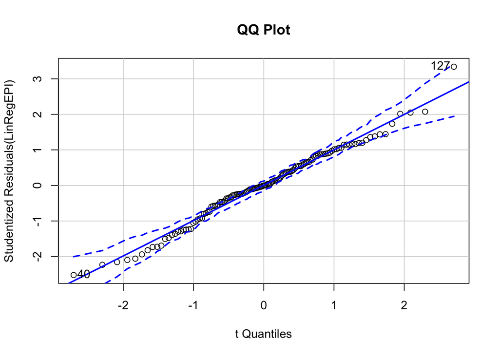

```
## [1]  40 127
```

```r
qqPlot(LinRegEPI, main="QQ Plot")
```

- **Multicollinearity**, the predictors are no highly correlated:

```r
# collinearity?
vif(LinRegEPI) > 4 # problem if some are TRUE
```

```
## corruptionIndex    scoreEconomy      scorepress
##           FALSE           FALSE           FALSE
```

```r
# Heteroskedastic?
ncvTest(LinRegEPI)$p<0.05
```

```
## [1] TRUE
```

- **Outliers**. Outliers are always present. In practice, you can not solve any issue if you are not controlling the presence of outliers, if they could be controlled:

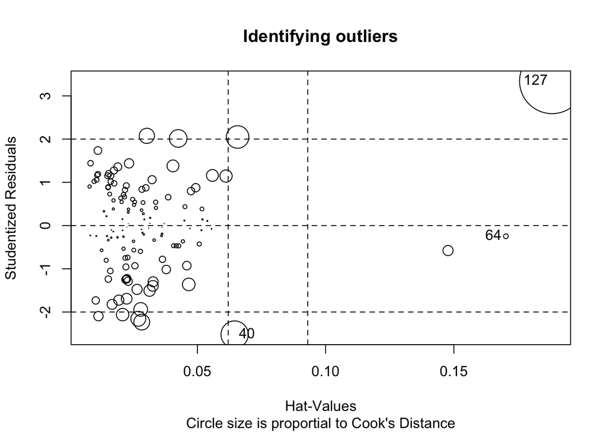

```
##        StudRes        Hat       CookD
## 40  -2.5213589 0.06450724 0.105087771
## 64  -0.2481556 0.17029510 0.003183753
## 127  3.3406953 0.18830904 0.598625540
```

```r
influencePlot(LinRegEPI,
              id.method="noteworthy",
              id.n=2,
              main="Identifying outliers",
              sub="Circle size is proportial to Cook's Distance")
```

When outliers are prominent, you could ask for *robust regression*:

```r
library(MASS)
LinRegEPI_R = rlm(environment ~ corruptionIndex + scoreEconomy + scorepress,
                data = indexes)

summary(LinRegEPI_R)
```

```
##
## Call: rlm(formula = environment ~ corruptionIndex + scoreEconomy +
##     scorepress, data = indexes)
## Residuals:
##      Min       1Q   Median       3Q      Max
## -26.8916  -6.5786  -0.3437   7.4061  36.6714
##
## Coefficients:
##                 Value   Std. Error t value
## (Intercept)     20.0001  9.2062     2.1725
## corruptionIndex  0.3681  0.0803     4.5858
## scoreEconomy     5.0979  1.5000     3.3987
## scorepress      -0.0354  0.0930    -0.3806
##
## Residual standard error: 10.66 on 125 degrees of freedom
```

You don’t see a p.value now, but you can consider significant the coefficients whose *t value* (in absolute terms) is greater than two.

Above, you have corrected coefficients. The same coefficients kept significant. The directions are kept too. The effect of econonomy (EFI) has increased, while the intercept (value when all the rest is zero) has decreased.

You can also omit the outliers and see the effect on the regresssion:

```r
outCases=c(40,64,127)
indexes[outCases,]
```

```
##       Country ISO corruptionIndex scoreEconomy scorepress environment
## 40     Rwanda RWA              54         7.57      34.94       50.34
## 64      China CHN              40         6.40       8.59       65.10
## 127 Venezuela VEN              17         2.92      44.78       76.23
##     presscat environmentCat
## 40         1              0
## 64         1              0
## 127        1              1
```

```r
LinRegEPI_OUT = lm(environment ~ corruptionIndex + scoreEconomy + scorepress, data = indexes[-outCases,])

summary(LinRegEPI_OUT)
```

```
##
## Call:
## lm(formula = environment ~ corruptionIndex + scoreEconomy + scorepress,
##     data = indexes[-outCases, ])
##
## Residuals:
##      Min       1Q   Median       3Q      Max
## -22.4764  -6.0975  -0.3531   7.5999  26.1431
##
## Coefficients:
##                 Estimate Std. Error t value Pr(>|t|)
## (Intercept)     17.86344    9.60119   1.861 0.065216 .
## corruptionIndex  0.38508    0.07815   4.928 2.65e-06 ***
## scoreEconomy     5.85382    1.52971   3.827 0.000206 ***
## scorepress      -0.10233    0.09742  -1.050 0.295616
## ---
## Signif. codes:  0 '***' 0.001 '**' 0.01 '*' 0.05 '.' 0.1 ' ' 1
##
## Residual standard error: 10.26 on 122 degrees of freedom
## Multiple R-squared:  0.5305, Adjusted R-squared:  0.5189
## F-statistic: 45.95 on 3 and 122 DF,  p-value: < 2.2e-16
```

Notice the new Adjusted R-squared.

Finally in this section, let me show you now what to do when one of the X variables is a category:

- Set the reference for categorical variable. When one of your X variables is categorical, the result will show a coefficient for every level of the category but one. The one missing is the reference. It is needed because the coefficient informs the effect of a particular level when compared to the reference.

```r
# The function 'relevel' CAN NOT accept ordinals.
# This is why I did not set it as ordinal before.
# This variable has 3 levels. Let's choose '1' as the reference.
indexes$presscat=as.factor(indexes$presscat)
indexes$presscat <- relevel(indexes$presscat, ref = 1)
```

- Write the equation of the regression as usual:

```r
LinRegEPI_catX <- lm(environment ~ corruptionIndex + scoreEconomy + presscat,data = indexes)

summary(LinRegEPI_catX)
```

```
##
## Call:
## lm(formula = environment ~ corruptionIndex + scoreEconomy + presscat,
##     data = indexes)
##
## Residuals:
##      Min       1Q   Median       3Q      Max
## -26.1889  -5.7063  -0.0712   7.7190  30.5783
##
## Coefficients:
##                 Estimate Std. Error t value Pr(>|t|)
## (Intercept)     28.68526    8.45163   3.394 0.000925 ***
## corruptionIndex  0.38868    0.09104   4.269 3.87e-05 ***
## scoreEconomy     3.54757    1.49346   2.375 0.019062 *
## presscat2       -1.62576    2.63061  -0.618 0.537699
## presscat3       -1.02657    3.79998  -0.270 0.787492
## ---
## Signif. codes:  0 '***' 0.001 '**' 0.01 '*' 0.05 '.' 0.1 ' ' 1
##
## Residual standard error: 10.93 on 124 degrees of freedom
## Multiple R-squared:  0.4664, Adjusted R-squared:  0.4492
## F-statistic:  27.1 on 4 and 124 DF,  p-value: 3.648e-16
```

The result is telling you that the change from category 1 to category 2 does not have effect. The same applies for the change from 1 to 3 (from 2 to 3 is not informed).

Go to beginning.

## Logistic Regression

You need a logistic regression when your variable of interest is categorical. In this case, I will simply use the categorical version of EPI as my *explanandum* (Y):

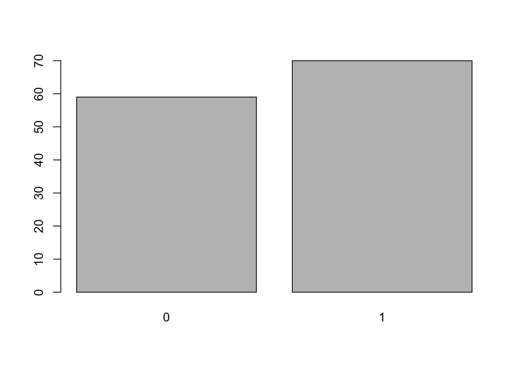

```r
barplot(table(indexes$environmentCat))
```

Before, the linear regression model computed the coefficients of X so that we predict the value of Y, being those continuous variables. In this case, having an dependent variable with only two values, ‘0’ and ‘1’, in Y, we will use a *binary logistic regression*. Then, the model will instead help you see which of the X variables will increase the ‘odds’ of getting a ‘1’.

The way to request this model is very similar to linear regression:

```r
# function 'glm' !
LogitEPI_a = glm(environmentCat ~ corruptionIndex + scoreEconomy,
                   data = indexes,
                   family = binomial())

# see full results:
summary(LogitEPI_a)
```

```
##
## Call:
## glm(formula = environmentCat ~ corruptionIndex + scoreEconomy,
##     family = binomial(), data = indexes)
##
## Deviance Residuals:
##     Min       1Q   Median       3Q      Max
## -2.0633  -0.8287   0.1968   0.8611   2.4499
##
## Coefficients:
##                 Estimate Std. Error z value Pr(>|z|)
## (Intercept)     -5.13431    1.94931  -2.634 0.008441 **
## corruptionIndex  0.07698    0.02026   3.800 0.000145 ***
## scoreEconomy     0.29992    0.33465   0.896 0.370134
## ---
## Signif. codes:  0 '***' 0.001 '**' 0.01 '*' 0.05 '.' 0.1 ' ' 1
##
## (Dispersion parameter for binomial family taken to be 1)
##
##     Null deviance: 177.89  on 128  degrees of freedom
## Residual deviance: 130.80  on 126  degrees of freedom
## AIC: 136.8
##
## Number of Fisher Scoring iterations: 5
```

Instead of the Adjusted RSquared, the GLM function offers the Akaike Information Criterion (AIC) as a *relative* measure of fitness. If you had two models, the smaller the AIC signals the best one of the two compared. Let’s make another model:

```r
# remember that presscat is factor
LogitEPI_b =glm(environmentCat ~ corruptionIndex + scoreEconomy + presscat,
                   data = indexes,
                   family = binomial())
summary(LogitEPI_b)
```

```
##
## Call:
## glm(formula = environmentCat ~ corruptionIndex + scoreEconomy +
##     presscat, family = binomial(), data = indexes)
##
## Deviance Residuals:
##     Min       1Q   Median       3Q      Max
## -1.9418  -0.8366   0.2137   0.8971   2.4145
##
## Coefficients:
##                 Estimate Std. Error z value Pr(>|z|)
## (Intercept)     -4.95802    1.98720  -2.495  0.01260 *
## corruptionIndex  0.06897    0.02366   2.915  0.00355 **
## scoreEconomy     0.31725    0.33555   0.945  0.34441
## presscat2       -0.05980    0.54435  -0.110  0.91253
## presscat3        0.43061    0.86086   0.500  0.61693
## ---
## Signif. codes:  0 '***' 0.001 '**' 0.01 '*' 0.05 '.' 0.1 ' ' 1
##
## (Dispersion parameter for binomial family taken to be 1)
##
##     Null deviance: 177.89  on 128  degrees of freedom
## Residual deviance: 130.35  on 124  degrees of freedom
## AIC: 140.35
##
## Number of Fisher Scoring iterations: 5
```

Now use the AIC:

```r
if (LogitEPI_a$aic < LogitEPI_b$aic){
    print("model 'a' is better")
}else{print("model 'b' is better")}
```

```
## [1] "model 'a' is better"
```

- How much is each variable in X influencing Y?

The coefficients computed are not directly interpretable, we need to exponentiate them:

```r
#getting coefficients
coeffsa=coef(summary(LogitEPI_a))
coeffsb=coef(summary(LogitEPI_b))
```

This is what you get for model a:

```r
data.frame(CoefficientExp=exp(coeffsa[,1]),Significant=coeffsa[,4]<0.05)
```

```
##                 CoefficientExp Significant
## (Intercept)        0.005891122        TRUE
## corruptionIndex    1.080021339        TRUE
## scoreEconomy       1.349748294       FALSE
```

This is what you get for model b:

```r
data.frame(CoefficientExp=exp(coeffsb[,1]),Significant=coeffsb[,4]<0.05)
```

```
##                 CoefficientExp Significant
## (Intercept)        0.007026814        TRUE
## corruptionIndex    1.071400513        TRUE
## scoreEconomy       1.373352410       FALSE
## presscat2          0.941954534       FALSE
## presscat3          1.538200355       FALSE
```

Exponentiating the resulting coefficients from the model is the first step to give an adequate interpretation. From there, you know there is a direct effect (increases the odds of Y=1) if the coefficient is greater than *one*, and an inverse effect if less than *one*, while its closeness to *1* would mean no effect. As before, we should be confident of a coefficient value if this were significant. Then, only corruption has a direct effect on the odds of Y=1.

Keep in mind that if the coefficient is categorical, the increase or decrease of the odds depends on what level of the category is the reference. In the case above, *presscat2* decreases the odds of Y=1 respect to *presscat1*.

An easier way to interpret those values, as the effect on the probability of ocurrence of the event **1** (that the environment index is OK), is by computing the marginal values:

```r
library(margins)
margins_LogitEPI_a = margins(LogitEPI_a)

marginalSummary=summary(margins_LogitEPI_a)

# just to see the results better:

data.frame(coeff=round(marginalSummary$AME,3),
           lower=round(marginalSummary$lower,3),
           upper=round(marginalSummary$upper,3),
           sig=marginalSummary$p<0.05)
```

```
##                 coeff  lower upper   sig
## corruptionIndex 0.013  0.008 0.018  TRUE
## scoreEconomy    0.051 -0.059 0.161 FALSE
```